# Analyses Pilot

Jeremy Zehr

11/12/2019

## Preparations and General observations

Reading the table, and making sure EventTime is numeric (important column)

```r
df.all <- read.pcibex("results40ppts.csv")

df.all$EventTime <- as.numeric(as.character(df.all$EventTime))
```

How long did each participant take?

```r
df.all %>% group_by(id) %>% summarise(duration = (max(EventTime, na.rm=TRUE) - min(EventTime, na.rm=TRUE))/60000)
```

```
## # A tibble: 39 x 2
##    id                       duration
##    <fct>                       <dbl>
##  1 54247957fdf99b691fb38467    12.1
##  2 55cf91b434e9060012e56fba    11.9
##  3 5751b9a8702d130006285f79     8.54
##  4 57b53ad8a18afd00013e0565    11.2
##  5 594bc2ffb37e5b0001ef7cd7    10.8
##  6 5a4c5ffbd5b53b0001f823fb    16.0
##  7 5a95e9fc89de8200013edcc7    25.8
##  8 5aa0b9e3dbdb470001ef2184     9.61
##  9 5ad38000b438910001aca894    12.0
## 10 5af7954257516b0001412633    13.8
## # … with 29 more rows
```

Preparing df.trials

```r
df.trials <- subset(df.all, grepl("input|practice", Type) & PennElementType%in%c("Scale","Var"))

# Forgot to log Dimension, adding it based on Item number:
dim.temp <- data.frame(Item.number=c(4:7,27:28), Dimension="Temperature", Nonce=FALSE)
dim.light <- data.frame(Item.number=c(8:11,29:30), Dimension="Light", Nonce=FALSE)
dim.sound <- data.frame(Item.number=c(12:15,31:32), Dimension="Sound", Nonce=TRUE)
dim.angle <- data.frame(Item.number=c(16:19,33:34), Dimension="Angle", Nonce=TRUE)
df.dim <- rbind(dim.temp,dim.light,dim.sound,dim.angle)
df.trials <- merge(df.trials,df.dim)
```

Focusing on input (leaving practice aside)

```r
df.input <- df.trials %>%
  filter(grepl("input", Type) & PennElementType=="Scale") %>%
  group_by(id, Dimension, Form, Force) %>%
  select(id,EventTime,Value,Dimension,Form,Force,Tested,Level,Nonce) %>%
  arrange(EventTime)
```

Did participants change direction while setting the dial?

```r
serialdifference <- function(t){
  t<-as.numeric(as.character(t))
  return(t-c(t[1],t[1:(length(t)-1)]))
}

df.input <- df.input %>% mutate(ValueDiff=serialdifference(Value)) %>% mutate(ConstantChange=all(ValueDiff<=0)|all(ValueDiff>=0))

summary((df.input %>% group_by(id) %>% summarise(overall=mean(ConstantChange)))$overall)
```

```
##    Min. 1st Qu.  Median    Mean 3rd Qu.    Max.
## 0.07465 0.64270 0.79771 0.74574 0.93648 1.00000
```

```r
df.input %>% group_by(Dimension) %>% summarise(overall=mean(ConstantChange)) %>% arrange(overall)
```

```
## # A tibble: 4 x 2
##   Dimension   overall
##   <fct>         <dbl>
## 1 Temperature   0.588
## 2 Light         0.653
## 3 Sound         0.756
## 4 Angle         0.788
```

```r
df.input %>% group_by(Dimension, Form, Force) %>% summarise(overall=mean(ConstantChange)) %>% arrange(overall)
```

```
## # A tibble: 16 x 4
## # Groups:   Dimension, Form [8]
##    Dimension   Form        Force overall
##    <fct>       <fct>       <fct>   <dbl>
##  1 Temperature excessive   Mid     0.526
##  2 Temperature comparative Mid     0.556
##  3 Light       comparative Mid     0.560
##  4 Temperature comparative Max     0.565
##  5 Light       excessive   Max     0.626
##  6 Light       excessive   Mid     0.651
##  7 Temperature excessive   Max     0.679
##  8 Sound       comparative Mid     0.688
##  9 Angle       comparative Max     0.694
## 10 Sound       excessive   Mid     0.730
## 11 Sound       comparative Max     0.752
## 12 Angle       excessive   Max     0.794
## 13 Angle       comparative Mid     0.809
## 14 Sound       excessive   Max     0.819
## 15 Light       comparative Max     0.831
## 16 Angle       excessive   Mid     0.837
```

Final values on trials

```r
df.input.final <- df.input %>% filter(EventTime == max(EventTime))
df.input.final$Value <- as.numeric(as.character(df.input.final$Value))

df.input.final$Increase <- df.input.final$Value > df.input.final$Level
df.input.final$Decrease <- df.input.final$Value < df.input.final$Level
# AdjustedIncrease == !Increase for mid-light (dim) and mid-angle; else == Increase
df.input.final$AdjustedIncrease <- df.input.final$Increase
midsoundangle <- df.input.final$Force=="Mid"&(df.input.final$Dimension=="Light"|df.input.final$Dimension=="Angle")
df.input.final$AdjustedIncrease[midsoundangle] <- (df.input.final$Increase[midsoundangle]|df.input.final$Decrease[midsoundangle])&!df.input.final$Increase[midsoundangle]
```

For each adjective (and each participant), IncreaseDiff = 1 if Increase on comparative & Decrease on excessive -1 if Decrease on comparative & Increase on excessive 0 if Same on comparative & excessive

```r
df.input.final <- df.input.final %>% group_by(id,Dimension,Force) %>% arrange(Form) %>%                                 mutate(IncreaseDiff=rep(0-diff(Increase),2),AdjIncreaseDiff=rep(0-diff(AdjustedIncrease),2))
```

## Stats

Did every participant change the dial’s value on every trial?

```r
all(df.input.final$Increase|df.input.final$Decrease)
```

```
## [1] TRUE
```

How many participants increased in each conditions?

```r
df.input.final %>%
  group_by(Dimension, Form, Force) %>%
  summarise( NIncrease=sum(Increase) , N = length(Increase) )
```

```
## # A tibble: 16 x 5
## # Groups:   Dimension, Form [8]
##    Dimension   Form        Force NIncrease     N
##    <fct>       <fct>       <fct>     <int> <int>
##  1 Temperature comparative Max          37    38
##  2 Temperature comparative Mid          36    38
##  3 Temperature excessive   Max           0    38
##  4 Temperature excessive   Mid           0    38
##  5 Light       comparative Max          37    38
##  6 Light       comparative Mid           2    38
##  7 Light       excessive   Max           1    38
##  8 Light       excessive   Mid          36    38
##  9 Sound       comparative Max          25    38
## 10 Sound       comparative Mid          12    38
## 11 Sound       excessive   Max           1    38
## 12 Sound       excessive   Mid          10    38
## 13 Angle       comparative Max          27    38
## 14 Angle       comparative Mid          34    38
## 15 Angle       excessive   Max           2    38
## 16 Angle       excessive   Mid           9    38
```

Logistic model predicting (adjusted) increase from Force (mid v max) and Form (comp v exc)

```r
df.input.final$id <- factor(df.input.final$id)
df.input.final$Form <- relevel(df.input.final$Form, "excessive")
df.input.final$Force <- relevel(df.input.final$Force, "Mid")
# Adding random structure for id wouldn't converge
md.all <- glmer(AdjustedIncrease ~ Form * Force + (1|Dimension),
                family="binomial",control=glmerControl(optimizer="bobyqa"), data=df.input.final)
summary(md.all)
```

```
## Generalized linear mixed model fit by maximum likelihood (Laplace
##   Approximation) [glmerMod]
##  Family: binomial  ( logit )
## Formula: AdjustedIncrease ~ Form * Force + (1 | Dimension)
##    Data: df.input.final
## Control: glmerControl(optimizer = "bobyqa")
##
##      AIC      BIC   logLik deviance df.resid
##    559.7    581.8   -274.9    549.7      603
##
## Scaled residuals:
##     Min      1Q  Median      3Q     Max
## -2.7860 -0.6895 -0.1497  0.5956  8.5982
##
## Random effects:
##  Groups    Name        Variance Std.Dev.
##  Dimension (Intercept) 0.1949   0.4415
## Number of obs: 608, groups:  Dimension, 4
##
## Fixed effects:
##                          Estimate Std. Error z value Pr(>|z|)
## (Intercept)               -1.0410     0.2896  -3.595 0.000324 ***
## Formcomparative            1.3722     0.2524   5.437 5.42e-08 ***
## ForceMax                  -2.6565     0.5413  -4.908 9.21e-07 ***
## Formcomparative:ForceMax   3.9674     0.6089   6.515 7.26e-11 ***
## ---
## Signif. codes:  0 '***' 0.001 '**' 0.01 '*' 0.05 '.' 0.1 ' ' 1
##
## Correlation of Fixed Effects:
##             (Intr) Frmcmp ForcMx
## Formcomprtv -0.482
## ForceMax    -0.218  0.249
## Frmcmprt:FM  0.190 -0.400 -0.890
```

Global stats support the truly-central hypothesis

## Plots

General plot, by force (mid v max) and by form (comp v exc)

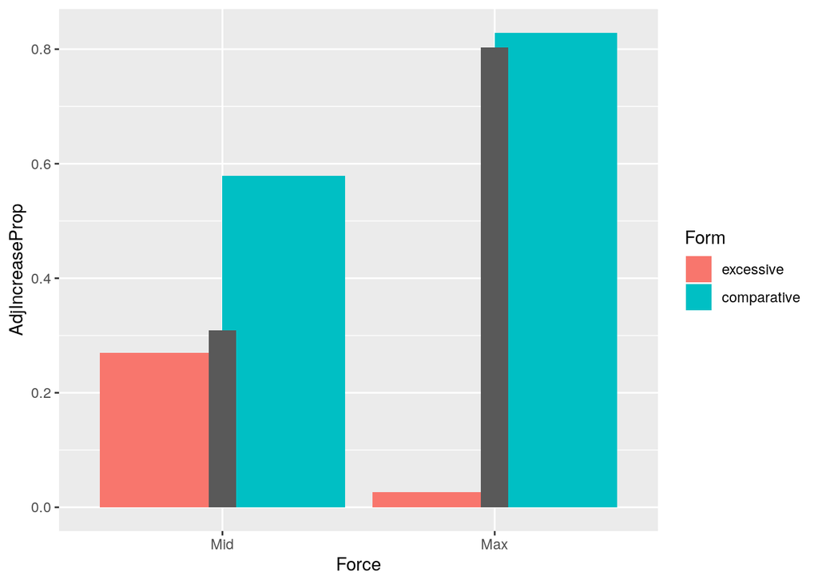

```r
ggplot(df.input.final %>% group_by(Force, Form) %>% summarise(AdjIncreaseProp = sum(AdjustedIncrease)/length(AdjustedIncrease), AdjIncreaseDiffProp = sum(AdjIncreaseDiff)/length(AdjIncreaseDiff))) +
  geom_bar(aes(x=Force, y=AdjIncreaseProp, fill=Form), stat="identity", position="dodge") +
  geom_bar(aes(x=Force,y=AdjIncreaseDiffProp), width=0.1, stat="identity", position="dodge")
```

Global picture is clear for Max (control) but complex for Mid

Real (FALSE) v Nonce (TRUE) adjectives

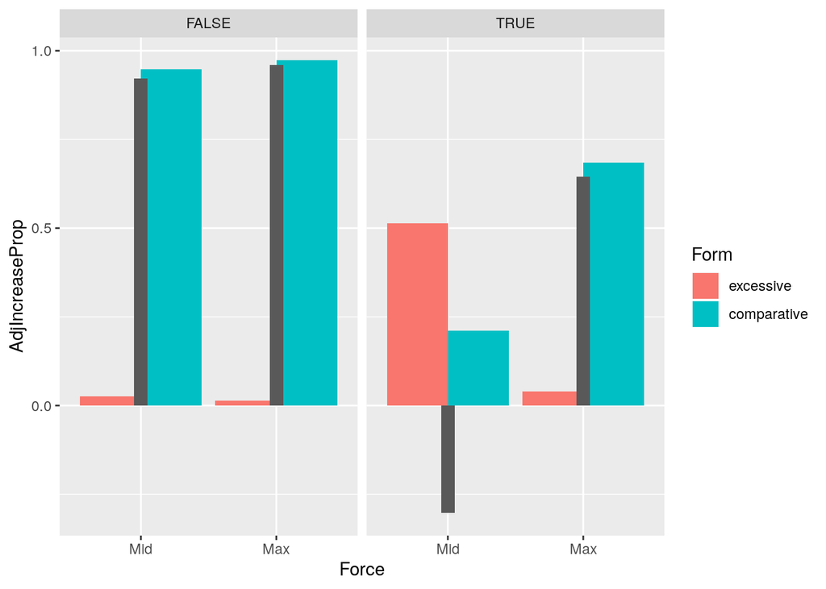

```r
ggplot(df.input.final %>% group_by(Force, Form, Nonce) %>% summarise(AdjIncreaseProp = sum(AdjustedIncrease)/length(AdjustedIncrease), AdjIncreaseDiffProp = sum(AdjIncreaseDiff)/length(AdjIncreaseDiff))) +
  geom_bar(aes(x=Force,y=AdjIncreaseProp,fill=Form), stat="identity", position="dodge") +
  geom_bar(aes(x=Force,y=AdjIncreaseDiffProp), width=0.1, stat="identity", position="dodge") +
  facet_wrap(~Nonce)
```

Clear picture for real adjectives, complex for nonce adjectives

Plotting each adjective separately

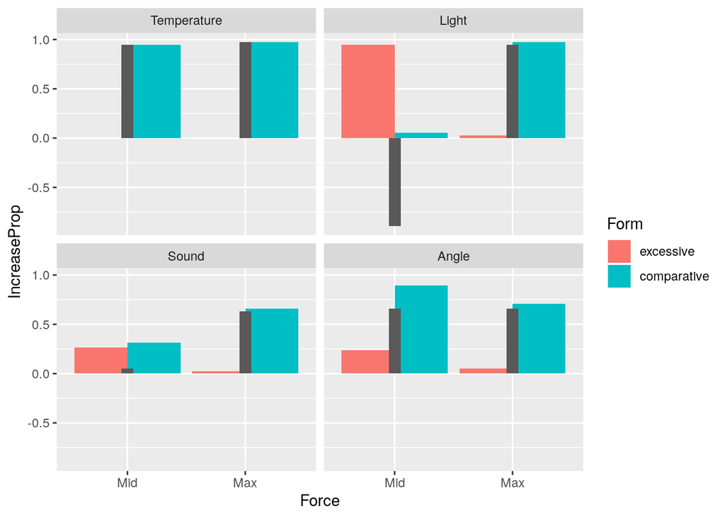

```r
# Raw Increase
ggplot(df.input.final %>% group_by(Force, Form, Dimension) %>% summarise(IncreaseProp = sum(Increase)/length(Increase), IncreaseDiffProp = mean(IncreaseDiff))) +
       geom_bar(aes(x=Force, y=IncreaseProp, fill=Form), stat="identity", position="dodge") +
       geom_bar(aes(x=Force,y=IncreaseDiffProp), width=0.1, stat="identity", position="dodge") +
        facet_wrap(~Dimension)
```

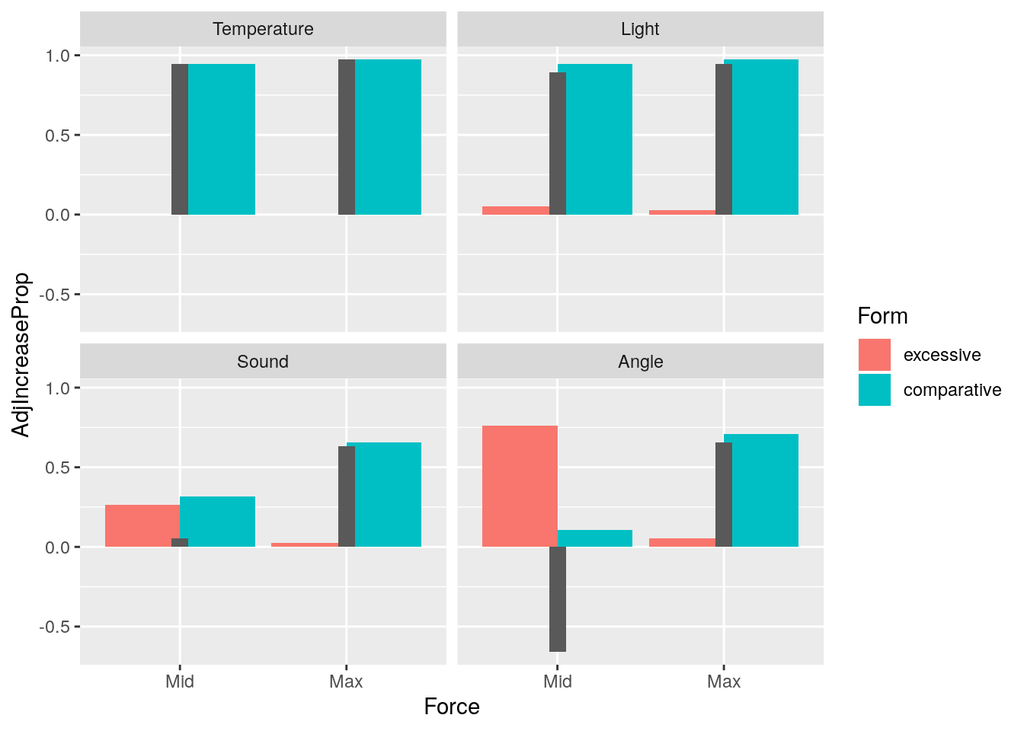

```r
# Adjusted Increase
ggplot(df.input.final %>% group_by(Force, Form, Dimension) %>% summarise(AdjIncreaseProp = sum(AdjustedIncrease)/length(AdjustedIncrease), AdjIncreaseDiffProp = mean(AdjIncreaseDiff))) +
  geom_bar(aes(x=Force, y=AdjIncreaseProp, fill=Form), stat="identity", position="dodge") +
  geom_bar(aes(x=Force,y=AdjIncreaseDiffProp), width=0.1, stat="identity", position="dodge") +
  facet_wrap(~Dimension)
```

Did turning the sound off make a difference?

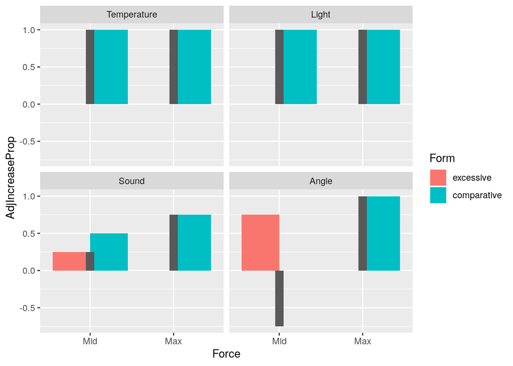

```r
ggplot(merge(df.input.final, df.all %>% filter(PennElementName=="sound") %>% select(id, Value) %>% rename(Sound = Value)) %>% filter(Sound=="off") %>% group_by(Force, Form, Dimension) %>% summarise(AdjIncreaseProp = sum(AdjustedIncrease)/length(AdjustedIncrease), AdjIncreaseDiffProp = mean(AdjIncreaseDiff))) +
  geom_bar(aes(x=Force, y=AdjIncreaseProp, fill=Form), stat="identity", position="dodge") +
  geom_bar(aes(x=Force,y=AdjIncreaseDiffProp), width=0.1, stat="identity", position="dodge") +
  facet_wrap(~Dimension)
```

Apparently not!